# Lab 05 - categorical data

# Using categorical data

```r
# Using data from package
data(Prestige, package = "carData")
```

Analizziamo se le persone che hanno avuto un’educazione maggiore, abbiano anche un livello di prestigio piu’ alto.

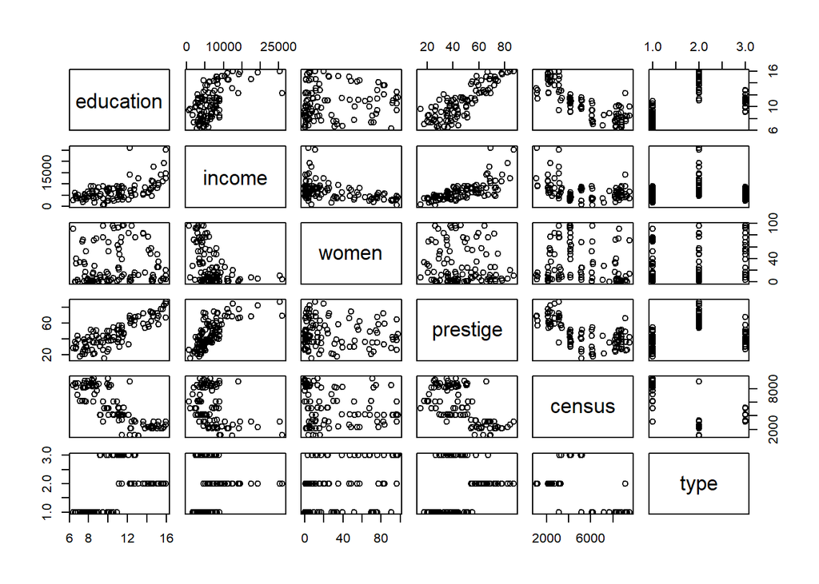

```r
plot(Prestige)
```

Sembrano esserci delle differenze nelle medie del prestigio, nei diversi tipi di lavoro.

## 1 - First model: income and education as predictors

Un primo modello con education e income come predittori. Analizziamo se le persone che hanno avuto un’educazione maggiore, abbiano anche un livello di prestigio piu’ alto.

```r
fit1 <- lm(prestige ~ income+education, data = Prestige)
summary(fit1)
```

```
##
## Call:
## lm(formula = prestige ~ income + education, data = Prestige)
##
## Residuals:
##      Min       1Q   Median       3Q      Max
## -19.4040  -5.3308   0.0154   4.9803  17.6889
##
## Coefficients:
##               Estimate Std. Error t value Pr(>|t|)
## (Intercept) -6.8477787  3.2189771  -2.127   0.0359 *
## income       0.0013612  0.0002242   6.071 2.36e-08 ***
## education    4.1374444  0.3489120  11.858  < 2e-16 ***
## ---
## Signif. codes:  0 '***' 0.001 '**' 0.01 '*' 0.05 '.' 0.1 ' ' 1
##
## Residual standard error: 7.81 on 99 degrees of freedom
## Multiple R-squared:  0.798,  Adjusted R-squared:  0.7939
## F-statistic: 195.6 on 2 and 99 DF,  p-value: < 2.2e-16
```

Vediamo che il coefficiente angolare e’ positivo per entrambi e molto forte per quanto riguarda l’educazione. Per entrambi, possiamo rifiutare l’ipotesi nulla con un p-value molto piccolo.

Il modello spiega circa il 79.39% della variabilita’. La F-statistic e’ molto grande per un p-value molto piccolo e percio’ rifiutiamo l’ipotesi nulla dell’utilizzo di un modello con solo $\beta_{0}$

### 1.1 - Verifying assumptions and Residuals checking

Andiamo a verificare se il modello è significativo e se rispetta le assunzioni usate per costruire il modello stesso:

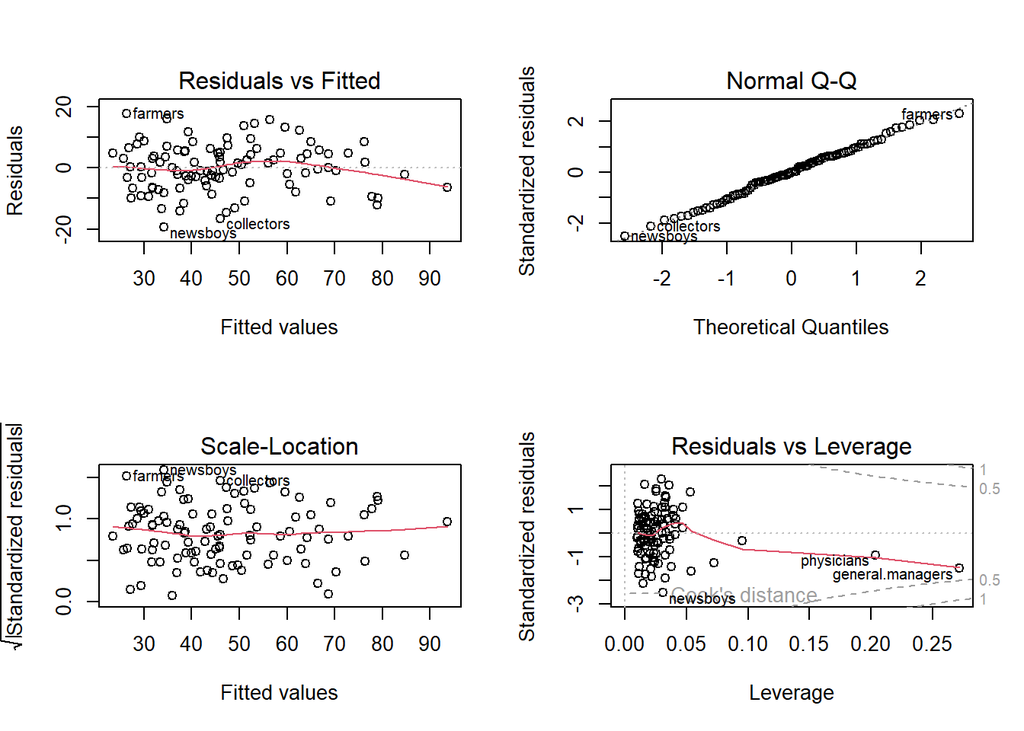

```r
# Create a 2x2 grill to include 4 graphs
par(mfrow=c(2,2));
plot(fit1)
```

- **Residuals vs Fitted** e’ un grafico dei valori stimati contro i residui; Ci serve per vedere se c’e’ qualche forma strutturale per vedere se stiamo sovrastimando o sottostimando il modello per alcuni valori di Y
  - In questo caso non vediamo una grande struttura, forse vi e’ una struttura quadratica.
  - La linea rossa e’ uno “smoother” uno stimatore snon-parametrico della forma della relazione tra fitted values e residuals. Ci interessa che la linea rossa sia sullo 0, e che sia orizzontale. Vediamo che in questo caso e’ molto vicina alle nostre aspettative.
- **Normal QQplot**, il grafico in cui si analizza l’ ipotesi della normalita’ dei residui.
- **Scale-Location** (valori stimati vs sqrt(abs(standardized residuals))), “la versione positiva dei residui”.
  - Quello che si vede e’ la stima della radice quadrata della varianza.
  - Se ci fossero problemi di eteroschedasticita’, sarebbe particolarmente facile vedere una forma funzionale dei residui (che cresce al crescere dei residui) in questo grafico. Non e’ il nostro caso.
- **Residuals vs Leverage**
  - Leverage contiene l’informazione riguardo alla presenza di variabili che hanno sull’asse delle x dei valori “bizzarri”, diversi dal resto del campione
  - Vediamo cio’ contro i residui standardizzati.
  - Vediamo che in generale non sono problematiche, a parte due professioni che sono particolari dal punto di vista dell’asse delle x.

Nel nostro caso, le assunzioni del modello non sembrano particolarmente problematiche e l’inferenza che andiamo a fare e’ particolarmente buona. Questo e’ confermato dai dati e dai residui che sembrano essere normali ed omoschedastici. Inoltre, non sembra che abbiamo trascurato altre relazioni importanti dei dati.

## 2 - Let’s consider more predictors

Tipicamente, per capire se il nostro modello e’ stato ben specificato, controlliamo se ci sono altri predittori inclusi nel dataset che possono aiutare a catturare variabilità aggiuntiva.

Passiamo quindi ad una fase di plotting, utilizzando degli scatterplots per i potenziali predittori (non presenti nel modello) al fine di analizzare come i residui del modello si comportano.

Se vedessimo una forma funzionale in questi grafici, sarebbe evidente che non stiamo includendo parte della variabilita’.

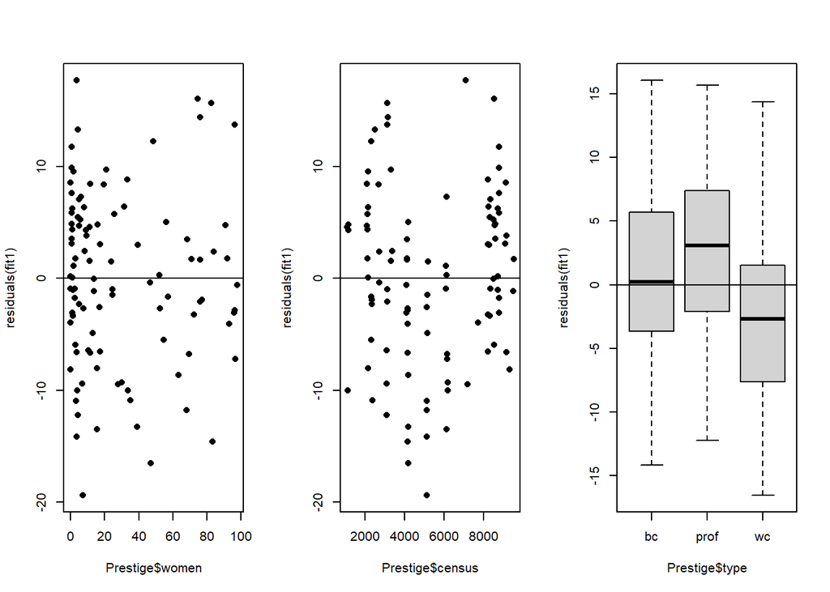

```r
par(mfrow=c(1,3),pch=16)
plot(residuals(fit1) ~ Prestige$women); abline(h = 0)
plot(residuals(fit1) ~ Prestige$census); abline(h = 0)
plot(residuals(fit1) ~ Prestige$type); abline(h = 0)
```

- I residui di `women`, che sono molto sparsi, non fanno intravedere una qualche forma di relazione che sia rilevante e percio’ possiamo escluderla dal modello.
- I residui di `census` sembrano mostrare una qualche relazione, quasi quadratica.
- In `type` invece, vediamo che vi e’ una palese differenza tra le medie, e possiamo pensare di non aver catturato completamente quel tipo di variabilita’.

### 2.1 - Extending the model

Proviamo ad aggiungere `census` e `type` al modello, grazie ad `update()`:

```r
fit_wthcensus <- update(fit1, . ~ .+census)
# fit_wthcensus <- lm(prestige ~ education+income+census, data = Prestige)
summary(fit_wthcensus)
```

```
##
## Call:
## lm(formula = prestige ~ income + education + census, data = Prestige)
##
## Residuals:
##      Min       1Q   Median       3Q      Max
## -19.0412  -5.2392  -0.0678   5.1002  18.5172
##
## Coefficients:
##               Estimate Std. Error t value Pr(>|t|)
## (Intercept) -1.507e+01  8.266e+00  -1.824   0.0713 .
## income       1.300e-03  2.312e-04   5.622 1.78e-07 ***
## education    4.653e+00  5.907e-01   7.876 4.66e-12 ***
## census       5.762e-04  5.334e-04   1.080   0.2827
## ---
## Signif. codes:  0 '***' 0.001 '**' 0.01 '*' 0.05 '.' 0.1 ' ' 1
##
## Residual standard error: 7.804 on 98 degrees of freedom
## Multiple R-squared:  0.8004, Adjusted R-squared:  0.7943
## F-statistic:   131 on 3 and 98 DF,  p-value: < 2.2e-16
```

Vediamo che l’aggiunta di `census`, influenza anche la forza di `income`.

Si vede una relazione forte per quanto riguarda `census` sebbene sia poco significativa se presa singolarmente (il p-value non e’ molto signifcativo). Dato che la relazione precedentemente vista era quadratica, non sarebbe una brutta idea aggiungere census al quadrato.

Inoltre, l’ $R^{2}$ e’ aumentato di relativamente poco rispetto a prima ed il Residual Standard Error e’ diminuito di poco.

```r
fit_wthtype <- update(fit1, . ~ .+type)
#fit_wthtype <- lm(prestige ~ education+income+type, data = Prestige)
summary(fit_wthtype)
```

```
##
## Call:
## lm(formula = prestige ~ income + education + type, data = Prestige)
##
## Residuals:
##      Min       1Q   Median       3Q      Max
## -14.9529  -4.4486   0.1678   5.0566  18.6320
##
## Coefficients:
##               Estimate Std. Error t value Pr(>|t|)
## (Intercept) -0.6229292  5.2275255  -0.119    0.905
## income       0.0010132  0.0002209   4.586 1.40e-05 ***
## education    3.6731661  0.6405016   5.735 1.21e-07 ***
## typeprof     6.0389707  3.8668551   1.562    0.122
## typewc      -2.7372307  2.5139324  -1.089    0.279
## ---
## Signif. codes:  0 '***' 0.001 '**' 0.01 '*' 0.05 '.' 0.1 ' ' 1
##
## Residual standard error: 7.095 on 93 degrees of freedom
##   (4 observations deleted due to missingness)
## Multiple R-squared:  0.8349, Adjusted R-squared:  0.8278
## F-statistic: 117.5 on 4 and 93 DF,  p-value: < 2.2e-16
```

Essendo una variabile categoriale, R aggiunge due parametri al modello, che risultano entrambi non significativi.

La presenza di type indebolisce la relazione di `income` ed `education`.

Vediamo un importante aumento del $R^{2}$ probabilmente dovuto al fatto che si sono aggiunti due predittori ed e’ quindi poco importante e trascurabile, soprattutto perche’ e’ aumentato di appena 3 punti circa.

Dunque, nessuna delle due variabili sembra essere significativa se presa singolarmente.

### 2.2 - Comparing the new models

Alternativamente possiamo arrivare alle stesse conclusioni usando `AIC` ed `ANOVA` (perche’ siamo nel caso dei nested models) per i confronti:

```r
AIC(fit1); AIC(fit_wthcensus); AIC(fit_wthtype)
```

```
## [1] 713.7251
```

```
## [1] 714.5177
```

```
## [1] 669.0151
```

o più semplicemnte

```r
AIC(fit1, fit_wthcensus, fit_wthtype)
```

```
## Warning in AIC.default(fit1, fit_wthcensus, fit_wthtype): models are not all
## fitted to the same number of observations
```

```
##               df      AIC
## fit1           4 713.7251
## fit_wthcensus  5 714.5177
## fit_wthtype    6 669.0151
```

Da questo punto di vista sembra che fit_wthtype sia migliore.

### 2.3 - Dealing with Missing Data/Observations

Notiamo che R stampa un warning. Nel `summary` di `fit_wthtype` in effetti notiamo che quando usiamo la variabile `type` cambiano il numero di gradi di libertà a disposizione del modello: questo perché la variabile `type` ha dei valori mancanti ed R elimina le osservazioni che contengono dati mancanti quando stima il modello:

```r
dim(fit_wthcensus$model)
```

```
## [1] 102   4
```

```r
dim(fit_wthtype$model)
```

```
## [1] 98  4
```

Infatti non potremmo fare un `anova(fit1, fit_wthtype)` in queste condizioni, dato che non e’ possibile calcolare la matrice di disegno ed ANOVA ha bisogno di calcolare le $n-p$.

Potrebbe valere la pena di tralasciare `type` come possibile predittore perche’ ci farebbe perdere molta informazione. Esistono tecniche di imputazione dei dati mancanti per risolvere questo problema, ma non ne facciamo uso qua.

Prima di tutto andiamo a vedere quali tipi, hanno dati mancanti:

```r
Prestige[is.na(Prestige$type),]
```

```
##             education income women prestige census type
## athletes        11.44   8206  8.13     54.1   3373 <NA>
## newsboys         9.62    918  7.00     14.8   5143 <NA>
## babysitters      9.46    611 96.53     25.9   6147 <NA>
## farmers          6.84   3643  3.60     44.1   7112 <NA>
```

Per poter confrontare i modelli dobbiamo essere sicuri che **tutti i modelli siano stimati usando lo stesso dataset**, perche’ la verosimiglianza deve essere calcolata sulle stesse osservazioni.

Percio’ possiamo decide di eliminare 4 osservazioni per confrontare i modelli in maniera valida. Abbiamo principalmente due modi:

- Rispecificare i dati
- Specificare solo i dati non mancanti

```r
# 1 - Specify a subset dataset with no missing data
sfit1 <- lm(prestige ~ education+income, data = Prestige[!is.na(Prestige$type),])

# 2 - Use the subset option in lm
sfit_wthcensus <- lm(prestige ~ education+income+census, data = Prestige,
                     subset = !is.na(Prestige$type))

dim(sfit1$model); dim(sfit_wthcensus$model)
```

```
## [1] 98  3
```

```
## [1] 98  4
```

```r
# 102 obs - 3 est. param. vs 99 obs - 4 est. param.
c(fit1$df.residual, sfit1$df.residual)
```

```
## [1] 99 95
```

Procediamo.

Dato che `sfit_wthcensus` e `sfit_wthtype` non sono annidati facciamo un confronto basato solo su AIC

```r
AIC(sfit1, sfit_wthcensus, fit_wthtype)
```

```
##                df      AIC
## sfit1           4 676.6695
## sfit_wthcensus  5 676.8536
## fit_wthtype     6 669.0151
```

`fit_wthtype` ha una performance migliore, sebbene i coefficienti per i due singoli livelli non siano significativi.

```r
# anova(fit1, fit_wthcensus)
anova(sfit1,fit_wthtype)
```

```
## Analysis of Variance Table
##
## Model 1: prestige ~ education + income
## Model 2: prestige ~ income + education + type
##   Res.Df    RSS Df Sum of Sq      F   Pr(>F)
## 1     95 5272.4
## 2     93 4681.3  2    591.16 5.8721 0.003966 **
## ---
## Signif. codes:  0 '***' 0.001 '**' 0.01 '*' 0.05 '.' 0.1 ' ' 1
```

Il modello in cui viene inclusa la variabile `type` risulta significativamente migliore del modello senza la variabile in un test anova.

Infatti, possiamo rifiutare (con un basso p-value) l’ipotesi nulla che $\beta_{3}, \beta_{4}$ siano pari a 0.

Invece per `census` il p-value non e’ significativo e non fa aumentare di piu’ la capacita’ predittiva del modello. Un altro motivo per escludere `census` e’ che il censo non è veramente una variabile numerica che esprime una misura ma è una categorizzazione fatta dall’istituto di statistica ha più senso mantenere la variabile categoriale che descrive una vera caratteristica del dato (sebbene anche `type` sia un’informazione non misurabile empiricamente ma frutto di una valutazione fatta da persone).

Possiamo anche notare che `type` e `census` sono associati tra loro e includere entrambe le variabili potrebbe non portare a miglioramenti in termini di bontà di adattamento:

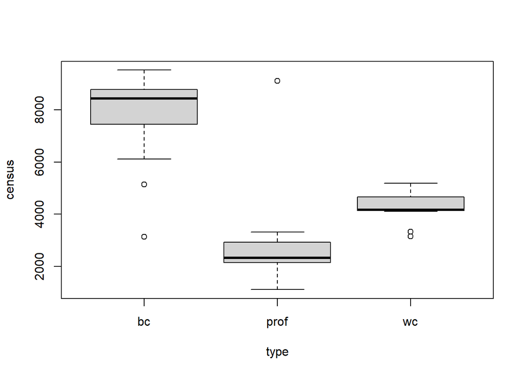

```r
plot(census~type,data=Prestige)
```

Infatti includere `type` elimina gran parte della forma residua di relazione tra `census` e i residui:

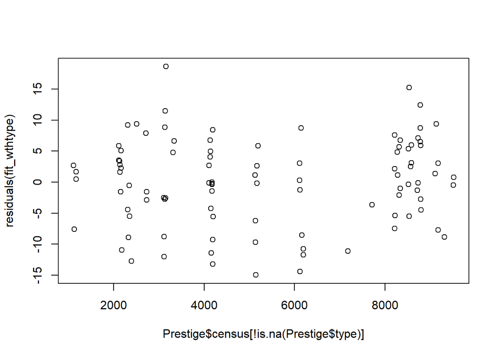

```r
plot(Prestige$census[!is.na(Prestige$type)],
     residuals(fit_wthtype))
```

## 3 - Understanding categorial variables in R

Come fa R per stimare questa variabile categoriale?

Andiamo adesso a capire che modello è `fit_wthtype` esattamente e come R ha inserito nel modello una variale esplicativa che noi vediamo stampata come stringa nel dataset:

```r
## rewrite the dataset to only include complete information
Prestige <- Prestige[!is.na(Prestige$type),]

# what is type
class(Prestige$type)
```

```
## [1] "factor"
```

```r
head(Prestige$type)
```

```
## [1] prof prof prof prof prof prof
## Levels: bc prof wc
```

R identifica `type` come una variabile categoriale con tre livelli `bc`, `prof` e `wc`.

```r
# They coincide!
colSums(model.matrix(fit_wthtype))
```

```
## (Intercept)      income   education    typeprof      typewc
##       98.00   680008.00     1057.92       31.00       23.00
```

```r
table(Prestige$type)
```

```
##
##   bc prof   wc
##   44   31   23
```

I tipi coincidono esattamente ai lavoratori per ciascuna categoria.

### 3.1 - Dummy encoding for type

```r
fit_wthtype$coefficients
```

```
##  (Intercept)       income    education     typeprof       typewc
## -0.622929165  0.001013193  3.673166052  6.038970651 -2.737230718
```

La variabile `type` può avere tre valori: quando la aggiungiamo al modello aggiungiamo di fatto due coefficienti che descrivono la differenza del valore dell’intercetta per due dei tre gruppi rispetto ad un primo gruppo che è il gruppo di base (reference leve).

In pratica, vengono stimati tre iper-piani, uno per ogni gruppo con tre intercette diverse. Ci risultano tre sotto-modelli diversi:

Il livello `bc` della variabile `type` è il livello di riferimento, le stime per i lavori negli altri tipi di lavoro sono derivate rispetto al livello `bc`.

Perché `bc`? R ordina i livelli in ordine alfabetico e prende il primo livello come modello di riferimento. R poi crea due variabili dicotomiche per i livelli che non sono quello di riferimento

```r
head(model.matrix(fit_wthtype))
```

```
##                     (Intercept) income education typeprof typewc
## gov.administrators            1  12351     13.11        1      0
## general.managers              1  25879     12.26        1      0
## accountants                   1   9271     12.77        1      0
## purchasing.officers           1   8865     11.42        1      0
## chemists                      1   8403     14.62        1      0
## physicists                    1  11030     15.64        1      0
```

Vediamo bene come viene vista la matrice di modello da R, dopo la trasformazione di `type` l’assenza di `typeprof = 0` e `typewc = 0` codifica `bc`.

```r
fit_wthtype$coefficients
```

```
##  (Intercept)       income    education     typeprof       typewc
## -0.622929165  0.001013193  3.673166052  6.038970651 -2.737230718
```

I coefficienti legati ad `education` ed `income` sono positivi: lavori in cui si guadagna di più o per cui si è studiato più a lungo tendono ad essere più prestigiosi.

La stima di `typeprof` e’ altamente positiva, quindi le persone in un lavoro professionale hanno un prestigio ben piu’ alto di quelle che lavorano in `bc`, data dalla intercept (a parita’ di income ed education).

In altre parole, a parita’ di `income` ed `education` , lavorare in lavori professionali porta ad un aumento di 6 punti (`typeprof`), mentre lavorare in lavori di tipo `wc` porta ad un decremento di 2.7, rispetto al reference level `bc` che si identifica come l’intercetta.

Diamo un occhio ai dati originali e i valori stimati dal modello in cui permettiamo di avere tre intercette diverse per ogni gruppo:

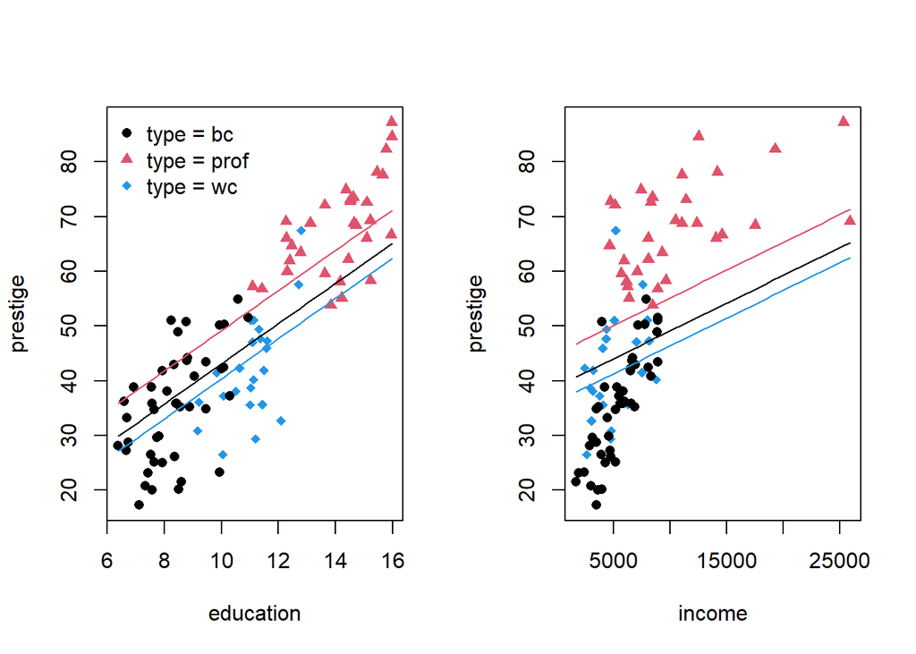

```r
par(mfrow=c(1,2))
plot(prestige~education, data=Prestige[!is.na(Prestige$type),],
     pch=16+ifelse(Prestige$type == "prof",1,0)+ifelse(Prestige$type == "wc",2,0),
     col=1+ifelse(Prestige$type == "prof",1,0)+ifelse(Prestige$type == "wc",3,0))
#### add the three lines evaluated at mean income
nd <- data.frame(education = rep(seq(min(Prestige$education),max(Prestige$education),
                                     length.out=40), times=3),
                 income = rep(mean(Prestige$income), 40*3),
                 type = rep(levels(Prestige$type), each=40))
lines(nd$education[nd$type == "bc"], predict(fit_wthtype,nd[nd$type == "bc",]))
lines(nd$education[nd$type == "prof"], predict(fit_wthtype,nd[nd$type == "prof",]),col=2)
lines(nd$education[nd$type == "wc"], predict(fit_wthtype,nd[nd$type == "wc",]),col=4)
legend("topleft", col = c(1,2,4), pch = c(16,17,18), bty = "n",
       legend = c("type = bc", "type = prof","type = wc"))
plot(prestige~income, data=Prestige[!is.na(Prestige$type),],
     pch=16+ifelse(Prestige$type == "prof",1,0)+ifelse(Prestige$type == "wc",2,0),
     col=1+ifelse(Prestige$type == "prof",1,0)+ifelse(Prestige$type == "wc",3,0))
#### add the three lines evaluated at mean income
nd <- data.frame(education = rep(mean(Prestige$education), 40*3),
                 income = rep(seq(min(Prestige$income),max(Prestige$income),
                                     length.out=40), times=3),
                 type = rep(levels(Prestige$type), each=40))
lines(nd$income[nd$type == "bc"], predict(fit_wthtype,nd[nd$type == "bc",]))
lines(nd$income[nd$type == "prof"], predict(fit_wthtype,nd[nd$type == "prof",]),col=2)
lines(nd$income[nd$type == "wc"], predict(fit_wthtype,nd[nd$type == "wc",]),col=4)
```

Si nota che i diversi gruppi hanno effettivamente livelli medi diversi di `prestige` e che la variabile `type` interagisce con `education` e `income`. Infatti income, non e’ ugualmente distribuito tra i livelli delle diverse professioni.

Quello che potrebbe succedere e’ che la relazione tra queste variabili sia piu’ forte in alcuni gruppi rispetto ad altri! Conseguentemente il coefficiente angolare nei tre gruppi puo’ cambiare.

### 3.2 - Interactions

Come possiamo inserire questa interazione con gli altri predittori nel modello?

Possiamo stimare un modello in cui oltre a ad avere tre diverse intercette possiamo avere dei coefficienti angolari diversi per ogni gruppo, cioè permettere che la relazione tra i predittori e la variabile risposta sia diversa per ogni gruppo.

Iniziamo da un modello piuttosto complesso in cui permettiamo a `type` di interagire con `income` o `education` e permettiamo quindi che i coefficienti angolari per entrambi i predittori numerici siano diversi per ognuno dei tre gruppi.

```r
fit_intrall <- lm(prestige~ income*type + education*type,
                  data = Prestige,  subset = !is.na(Prestige$type))
```

Il modello stimato è il seguente:

$$Y = \beta_{0} + \beta_{1}X_{1} +
\beta_{2}X_{2} + \beta_{3}v_{3} + \beta_{4}v_{4} + \gamma_{3}X_{1}v_{3}
+ \gamma_{4}X_{1}v_{4} + \gamma_{5}X_{2}v_{3} + \gamma_{6}X_{2}v_{4} +
\varepsilon$$
Dove:

- $\beta_{1}X_{1} = \beta_{inc}\cdot income_{i}$
- $\beta_{2}X_{2} = \beta_{educ}\cdot education_{i}$
- $\beta_{3}v_{3} = \beta_{type:prof} \cdot \text{type:prof}$
- $\beta_{4}v_{4} = \beta_{type:wc} \cdot \text{type:wc}$
- $\gamma_{3}X_{i}v_{3} = \beta_{educ,type:prof} \cdot \text{education}_i \cdot \text{type:prof}$
- $\gamma_{4}X_{i}v_{4} = \beta_{educ,type:wc} \cdot \text{education}_i \cdot \text{type:wc}$
- $\gamma_{5}X_{i}v_{3} = \beta_{inc,type:prof} \cdot \text{income}_i \cdot \text{type:prof}$
- $\gamma_{6}X_{i}v_{4} = \beta_{inc,type:wc} \cdot \text{income}_i \cdot \text{type:wc}$
- $\varepsilon_i$ è l’errore $\varepsilon_i \sim N(0, \sigma^2)$ (NB: c’è un solo parametro $\sigma$ che descrive la variabilità dell’errore per tutti i gruppi).

Per ogni gruppo quindi viene stimato un modello diverso:

- Per `bc`:$Y_i = \beta_0 + \beta_{ed} * \text{education}_i + \beta_{inc} \text{income}_i + \epsilon_i$
- Per `prof`: $Y_i = \beta_0 + \beta_{ed} * \text{education}_i + \beta_{inc} \text{income}_i + \beta_{type:prof} \text{type:prof} + \beta_{ed,type:prof} * \text{education}_i * \text{type:prof} + \beta_{inc,type:prof} * \text{income}_i * \text{type:prof} + \epsilon_i$
- Per `wc`: $Y_i = \beta_0 + \beta_{ed} * \text{education}_i + \beta_{inc} * \text{income}_i + \beta_{type:wc} \text{type:wc} + \beta_{ed,type:wc} * \text{education}_i * \text{type:wc} + \beta_{inc,type:wc} * \text{income}_i * \text{type:wc} + \epsilon_i$

Vediamo un riasssunto della stima ottenuta:

```r
summary(fit_intrall)
```

```
##
## Call:
## lm(formula = prestige ~ income * type + education * type, data = Prestige,
##     subset = !is.na(Prestige$type))
##
## Residuals:
##     Min      1Q  Median      3Q     Max
## -13.462  -4.225   1.346   3.826  19.631
##
## Coefficients:
##                      Estimate Std. Error t value Pr(>|t|)
## (Intercept)         2.276e+00  7.057e+00   0.323   0.7478
## income              3.522e-03  5.563e-04   6.332 9.62e-09 ***
## typeprof            1.535e+01  1.372e+01   1.119   0.2660
## typewc             -3.354e+01  1.765e+01  -1.900   0.0607 .
## education           1.713e+00  9.572e-01   1.790   0.0769 .
## income:typeprof    -2.903e-03  5.989e-04  -4.847 5.28e-06 ***
## income:typewc      -2.072e-03  8.940e-04  -2.318   0.0228 *
## typeprof:education  1.388e+00  1.289e+00   1.077   0.2844
## typewc:education    4.291e+00  1.757e+00   2.442   0.0166 *
## ---
## Signif. codes:  0 '***' 0.001 '**' 0.01 '*' 0.05 '.' 0.1 ' ' 1
##
## Residual standard error: 6.318 on 89 degrees of freedom
## Multiple R-squared:  0.8747, Adjusted R-squared:  0.8634
## F-statistic: 77.64 on 8 and 89 DF,  p-value: < 2.2e-16
```

Vediamo che molti parametri del modello non risultano significativi.

La variabilità della stima è aumentata, si confrontino per esempio gli intervalli di confidenza del parametro associato ad `education` nel modello in cui `type` non interagisce con gli altri predittori (`confint(fit_wthtype, parm ="education")`) e nel modello con l’interazione (`confint(fit_intrall, parm ="education")`): stiamo stimando molti parametri con un numero non poi così grande di osservazioni e rischiamo di sovra-parametrizzare il nostro modello.

### 3.3 - AIC and ANOVA

Tuttavia spieghiamo buona parte della variabilità della variabile risposta e vediamo che il test anova indica un miglioramento significativo della bontà di adattamento quando confrontiamo il modello con le interazioni contro il modello senza interazioni:

Per l’ ANOVA modelliamo il test:

- $H_{0}:$ all $\beta_{i}=0$
  - Contando anche i parametri di interazione.
- Any $\beta_{i} \neq 0$

```r
anova(fit_wthtype, fit_intrall)
```

```
## Analysis of Variance Table
##
## Model 1: prestige ~ income + education + type
## Model 2: prestige ~ income * type + education * type
##   Res.Df    RSS Df Sum of Sq      F    Pr(>F)
## 1     93 4681.3
## 2     89 3552.9  4    1128.4 7.0668 5.479e-05 ***
## ---
## Signif. codes:  0 '***' 0.001 '**' 0.01 '*' 0.05 '.' 0.1 ' ' 1
```

Rifiutiamo piuttosto confidentemente l’ipotesi nulla, conviene inserire i 4 parametri in piu’ pero’ potrebbero essercene di superflui. Aumentare la dimensionalita’ del modello crea un modello complesso e si rischia di aumentare la variabilita’ del livello stesso.

```r
#  anche AIC indica che fit_intrall è da preferire
AIC(fit_wthtype, fit_intrall)
```

```
##             df      AIC
## fit_wthtype  6 669.0151
## fit_intrall 10 649.9850
```

Anche AIC indica che `fit_intrall` è da preferire.

Possiamo anche cercare intervalli di confidenza per un parametro singolo.

```r
confint(fit_wthtype, parm = "education")
```

```
##              2.5 %   97.5 %
## education 2.401257 4.945075
```

```r
confint(fit_intrall, parm = "education")
```

```
##                2.5 %   97.5 %
## education -0.1887418 3.615291
```

E’ abbastanza chiaro che vi e’ un effetto di education, infatti per `fit_intrall` l’intervallo di confidenza si e’ allargato fino ad includere 0, mentre prima era molto significativo. Questo puo’ avere due motivi, o abbiamo trovato qualcosa che spiega meglio il target, o stiamo sovraparametrizzando il modello e stiamo stimando troppi parametri per fare un’inferenza dettagliata. Probabilmente, quest’ultimo e’ il nostro caso.

Guardiamo i valori stimati:

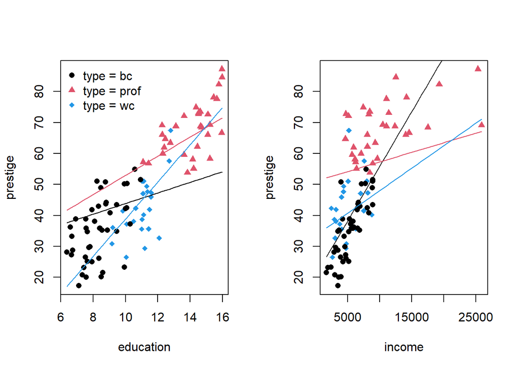

```r
par(mfrow=c(1,2))
plot(prestige~education, data=Prestige[!is.na(Prestige$type),],
     pch=16+ifelse(Prestige$type == "prof",1,0)+ifelse(Prestige$type == "wc",2,0),
     col=1+ifelse(Prestige$type == "prof",1,0)+ifelse(Prestige$type == "wc",3,0))
#### add the three lines evaluated at mean income
nd <- data.frame(education = rep(seq(min(Prestige$education),max(Prestige$education),
                                     length.out=40), times=3),
                 income = rep(mean(Prestige$income), 40*3),
                 type = rep(levels(Prestige$type), each=40))
lines(nd$education[nd$type == "bc"], predict(fit_intrall,nd[nd$type == "bc",]))
lines(nd$education[nd$type == "prof"], predict(fit_intrall,nd[nd$type == "prof",]),col=2)
lines(nd$education[nd$type == "wc"], predict(fit_intrall,nd[nd$type == "wc",]),col=4)
legend("topleft", col = c(1,2,4), pch = c(16,17,18), bty = "n",
       legend = c("type = bc", "type = prof","type = wc"))
plot(prestige~income, data=Prestige[!is.na(Prestige$type),],
     pch=16+ifelse(Prestige$type == "prof",1,0)+ifelse(Prestige$type == "wc",2,0),
     col=1+ifelse(Prestige$type == "prof",1,0)+ifelse(Prestige$type == "wc",3,0))
#### add the three lines evaluated at mean income
nd <- data.frame(education = rep(mean(Prestige$education), 40*3),
                 income = rep(seq(min(Prestige$income),max(Prestige$income),
                                     length.out=40), times=3),
                 type = rep(levels(Prestige$type), each=40))
lines(nd$income[nd$type == "bc"], predict(fit_intrall,nd[nd$type == "bc",]))
lines(nd$income[nd$type == "prof"], predict(fit_intrall,nd[nd$type == "prof",]),col=2)
lines(nd$income[nd$type == "wc"], predict(fit_intrall,nd[nd$type == "wc",]),col=4)
```

### 3.3 - Simplify the model

Tuttavia potrebbe essere un modello troppo variabile da usare in pratica, proviamo a cercare una via di mezzo in cui solo uno dei predittori continui interagisce con la variabile categoriale.

```r
fit_intred <- lm(prestige~education+income+type+education:type,
                 data = Prestige)
summary(fit_intred)
```

```
##
## Call:
## lm(formula = prestige ~ education + income + type + education:type,
##     data = Prestige)
##
## Residuals:
##      Min       1Q   Median       3Q      Max
## -15.1168  -4.1751   0.4384   5.1625  15.2362
##
## Coefficients:
##                      Estimate Std. Error t value Pr(>|t|)
## (Intercept)        -2.331e+00  7.783e+00  -0.299    0.765
## education           3.852e+00  9.406e-01   4.096 9.12e-05 ***
## income              1.052e-03  2.201e-04   4.782 6.66e-06 ***
## typeprof            2.209e+01  1.520e+01   1.454    0.149
## typewc             -2.822e+01  1.959e+01  -1.440    0.153
## education:typeprof -1.227e+00  1.304e+00  -0.941    0.349
## education:typewc    2.270e+00  1.872e+00   1.213    0.228
## ---
## Signif. codes:  0 '***' 0.001 '**' 0.01 '*' 0.05 '.' 0.1 ' ' 1
##
## Residual standard error: 7.036 on 91 degrees of freedom
## Multiple R-squared:  0.8411, Adjusted R-squared:  0.8306
## F-statistic: 80.27 on 6 and 91 DF,  p-value: < 2.2e-16
```

I parametri `education:typewc` e `education:typeprof` sono poco significativi, cio’ ci suggerisce che l’interazione tra education e type non sia significativa. Questo non toglie che `type` possa comunque essere significativa.

```r
fit_intrinc <- lm(prestige~education+income+type+income:type,
                  data = Prestige)
summary(fit_intrinc)
```

```
##
## Call:
## lm(formula = prestige ~ education + income + type + income:type,
##     data = Prestige)
##
## Residuals:
##      Min       1Q   Median       3Q      Max
## -12.8720  -4.8321   0.8534   4.1425  19.6710
##
## Coefficients:
##                   Estimate Std. Error t value Pr(>|t|)
## (Intercept)     -6.7272633  4.9515480  -1.359   0.1776
## education        3.0396961  0.6003699   5.063 2.14e-06 ***
## income           0.0031344  0.0005215   6.010 3.79e-08 ***
## typeprof        25.1723873  5.4669586   4.604 1.34e-05 ***
## typewc           7.1375093  5.2898177   1.349   0.1806
## income:typeprof -0.0025102  0.0005530  -4.539 1.72e-05 ***
## income:typewc   -0.0014856  0.0008720  -1.704   0.0919 .
## ---
## Signif. codes:  0 '***' 0.001 '**' 0.01 '*' 0.05 '.' 0.1 ' ' 1
##
## Residual standard error: 6.455 on 91 degrees of freedom
## Multiple R-squared:  0.8663, Adjusted R-squared:  0.8574
## F-statistic: 98.23 on 6 and 91 DF,  p-value: < 2.2e-16
```

`income:typeprof` e `income:typewc` sono molto piu’ significativi.

#### 3.3.1 - Tests

Questi due modelli sono annidati in `fit_intrall` quindi possiamo verificare tramite test anova se escludere l’interazione con uno dei predittori continui cambia in maniera significativa la bontà di adattamento del modello.

```r
anova(fit_intred, fit_intrall)
```

```
## Analysis of Variance Table
##
## Model 1: prestige ~ education + income + type + education:type
## Model 2: prestige ~ income * type + education * type
##   Res.Df    RSS Df Sum of Sq      F    Pr(>F)
## 1     91 4504.6
## 2     89 3552.9  2    951.77 11.921 2.588e-05 ***
## ---
## Signif. codes:  0 '***' 0.001 '**' 0.01 '*' 0.05 '.' 0.1 ' ' 1
```

Il modello in cui abbiamo rimosso la relazione tra `income` e `type` ha un p-value molto significativo.

Possiamo rifiutare convintamente l’ipotesi nulla $H_{0}$ che il coefficiente angolare di `income` sia lo stesso per tutti e tre i gruppi. E’ meglio usare un modello in cui permettiamo ad income di variare, oltre ad education.

```r
anova(fit_intrinc, fit_intrall)
```

```
## Analysis of Variance Table
##
## Model 1: prestige ~ education + income + type + income:type
## Model 2: prestige ~ income * type + education * type
##   Res.Df    RSS Df Sum of Sq      F  Pr(>F)
## 1     91 3791.3
## 2     89 3552.9  2     238.4 2.9859 0.05557 .
## ---
## Signif. codes:  0 '***' 0.001 '**' 0.01 '*' 0.05 '.' 0.1 ' ' 1
```

Evidenza non fortissima contro $H_0$, al tipico livello di significatività del 5% non rifiuteremmo $H_0$: escludere l’interazione `education` non riduce di molto la bontà di adattamento del modello.

Possiamo dire che questi due modelli sono in qualche modo confrontabili, la RSS dei due modelli non e’ cosi’ diversa, ma preferiamo il modello con `income:type`

Possiamo anche usare AIC, BIC o $R^2_{adj}$ per confrontare i vari modelli:

```r
# More likely to include more interactions
AIC(fit_wthtype, fit_intred, fit_intrinc, fit_intrall)
```

```
##             df      AIC
## fit_wthtype  6 669.0151
## fit_intred   8 669.2456
## fit_intrinc  8 652.3495
## fit_intrall 10 649.9850
```

```r
# More likely to choose simpler models
BIC(fit_wthtype, fit_intred, fit_intrinc, fit_intrall)
```

```
##             df      BIC
## fit_wthtype  6 684.5249
## fit_intred   8 689.9253
## fit_intrinc  8 673.0293
## fit_intrall 10 675.8346
```

```r
summary(fit_wthtype)$adj.r.square; summary(fit_intred)$adj.r.square
```

```
## [1] 0.8277545
```

```
## [1] 0.8306113
```

```r
summary(fit_intrinc)$adj.r.square; summary(fit_intrall)$adj.r.square
```

```
## [1] 0.8574365
```

```
## [1] 0.8633987
```

I criteri non concordano su quale sia il modello migliore. Cio’ non sorprende, non sappiamo quale sia effettivamente il modello migliore dato che non conosciamo il *vero* processo che genera i dati.

A seconda del criterio adottato sceglieremo un modello diverso come modello ottimale: l’importante è essere coerenti sulla metrica che si usa per confrontare i modelli.

Infine possiamo testare se questo modello è significativamente diverso dal modello senza interazione.

```r
anova(fit_wthtype, fit_intrinc)
```

```
## Analysis of Variance Table
##
## Model 1: prestige ~ income + education + type
## Model 2: prestige ~ education + income + type + income:type
##   Res.Df    RSS Df Sum of Sq      F    Pr(>F)
## 1     93 4681.3
## 2     91 3791.3  2    890.02 10.681 6.809e-05 ***
## ---
## Signif. codes:  0 '***' 0.001 '**' 0.01 '*' 0.05 '.' 0.1 ' ' 1
```

C’è una differenza significativa tra i RSS dei due modelli: l’interazione è necessaria per catturare qualche caratteristica presente nei dati.

Guardiamo i valori stimati dal modello `fit_intrinc`:

```r
summary(fit_intrinc)
```

```
##
## Call:
## lm(formula = prestige ~ education + income + type + income:type,
##     data = Prestige)
##
## Residuals:
##      Min       1Q   Median       3Q      Max
## -12.8720  -4.8321   0.8534   4.1425  19.6710
##
## Coefficients:
##                   Estimate Std. Error t value Pr(>|t|)
## (Intercept)     -6.7272633  4.9515480  -1.359   0.1776
## education        3.0396961  0.6003699   5.063 2.14e-06 ***
## income           0.0031344  0.0005215   6.010 3.79e-08 ***
## typeprof        25.1723873  5.4669586   4.604 1.34e-05 ***
## typewc           7.1375093  5.2898177   1.349   0.1806
## income:typeprof -0.0025102  0.0005530  -4.539 1.72e-05 ***
## income:typewc   -0.0014856  0.0008720  -1.704   0.0919 .
## ---
## Signif. codes:  0 '***' 0.001 '**' 0.01 '*' 0.05 '.' 0.1 ' ' 1
##
## Residual standard error: 6.455 on 91 degrees of freedom
## Multiple R-squared:  0.8663, Adjusted R-squared:  0.8574
## F-statistic: 98.23 on 6 and 91 DF,  p-value: < 2.2e-16
```

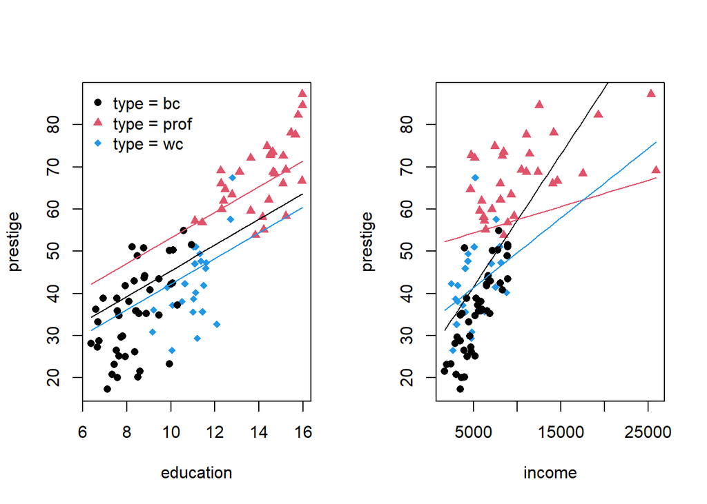

```r
par(mfrow=c(1,2))
plot(prestige~education, data=Prestige[!is.na(Prestige$type),],
     pch=16+ifelse(Prestige$type == "prof",1,0)+ifelse(Prestige$type == "wc",2,0),
     col=1+ifelse(Prestige$type == "prof",1,0)+ifelse(Prestige$type == "wc",3,0))
#### add the three lines evaluated at mean income
nd <- data.frame(education = rep(seq(min(Prestige$education),max(Prestige$education),
                                     length.out=40), times=3),
                 income = rep(mean(Prestige$income), 40*3),
                 type = rep(levels(Prestige$type), each=40))
lines(nd$education[nd$type == "bc"], predict(fit_intrinc,nd[nd$type == "bc",]))
lines(nd$education[nd$type == "prof"], predict(fit_intrinc,nd[nd$type == "prof",]),col=2)
lines(nd$education[nd$type == "wc"], predict(fit_intrinc,nd[nd$type == "wc",]),col=4)
legend("topleft", col = c(1,2,4), pch = c(16,17,18), bty = "n",
       legend = c("type = bc", "type = prof","type = wc"))
plot(prestige~income, data=Prestige[!is.na(Prestige$type),],
     pch=16+ifelse(Prestige$type == "prof",1,0)+ifelse(Prestige$type == "wc",2,0),
     col=1+ifelse(Prestige$type == "prof",1,0)+ifelse(Prestige$type == "wc",3,0))
#### add the three lines evaluated at mean income
nd <- data.frame(education = rep(mean(Prestige$education), 40*3),
                 income = rep(seq(min(Prestige$income),max(Prestige$income),
                                     length.out=40), times=3),
                 type = rep(levels(Prestige$type), each=40))
lines(nd$income[nd$type == "bc"], predict(fit_intrinc,nd[nd$type == "bc",]))
lines(nd$income[nd$type == "prof"], predict(fit_intrinc,nd[nd$type == "prof",]),col=2)
lines(nd$income[nd$type == "wc"], predict(fit_intrinc,nd[nd$type == "wc",]),col=4)
```

*Nota bene: fin’ora abbiamo usato `type` come codificata nel dataset. Guardando i grafici e i livelli di significatività dei coefficienti si potrebbe sosepettare che siano solo le professioni del gruppo `prof` ad avere una relazione diversa tra `education` e `prestige` e `income` e `prestige`, mentre le professioni in `"bc"` e `"wc"` si comportano in maniera simile. Possiamo creare una variabile dicotomica che differenzi solo i lavori `prof` da quelli `bc` e `wc` e fare una nuova analisi*

## 4 - Reference Levels in R

R usa il livello `"bc"` come livello di riferimento perché è il primo livello in ordine alfabetico. Tutti i coefficienti stimati nel modello sono quindi relativi al livello `bc`.

Possiamo cambiare il livello di riferimento in modo che i parametri del modello rappresentino la differenza di intercetta e coefficiente angolare rispetto ad livello che non sia `bc`, ma per esempio `prof` che funge quindi da livello di riferimento. Per fare questo in R dobbiamo usare l’argomento `levels` nella funzione `factor` per specificare i livelli della variabile:

```r
class(Prestige$type)
```

```
## [1] "factor"
```

```r
table(Prestige$type)
```

```
##
##   bc prof   wc
##   44   31   23
```

```r
levels(Prestige$type)
```

```
## [1] "bc"   "prof" "wc"
```

```r
# Reordering the levels'order
Prestige$newtype <- factor(Prestige$type, levels = c("prof","wc","bc"))

table(Prestige$newtype)
```

```
##
## prof   wc   bc
##   31   23   44
```

Se stimiamo dei modelli usando il tipo definito dal nostro ordine

```r
fit_newlevels <- lm(prestige ~ education + income + newtype, data = Prestige)
fit_newlevels$coefficients
```

```
##  (Intercept)    education       income    newtypewc    newtypebc
##  5.416041486  3.673166052  0.001013193 -8.776201369 -6.038970651
```

Vediamo che abbiamo dei coefficienti aggiuntivi stimati per i gruppi `wc` e `bc`. Inoltre, i valori numerici dei coefficienti sono diversi rispetto a prima.

Tuttavia a livello numerico non cambia nulla:

```r
fit_newlevels$coefficients
```

```
##  (Intercept)    education       income    newtypewc    newtypebc
##  5.416041486  3.673166052  0.001013193 -8.776201369 -6.038970651
```

```r
fit_wthtype$coefficients
```

```
##  (Intercept)       income    education     typeprof       typewc
## -0.622929165  0.001013193  3.673166052  6.038970651 -2.737230718
```

```r
nd <- data.frame(education = rep(mean(Prestige$education),3),
                 income = rep(mean(Prestige$income),3),
                 type = c("bc","prof","wc"),
                 newtype = c("bc","prof","wc"))
predict(fit_wthtype, nd)
```

```
##        1        2        3
## 46.05968 52.09865 43.32244
```

```r
predict(fit_newlevels, nd)
```

```
##        1        2        3
## 46.05968 52.09865 43.32244
```

```r
logLik(lm(prestige ~ income * newtype + education + newtype, data = Prestige,
    subset = !is.na(Prestige$newtype)))
```

```
## 'log Lik.' -318.1748 (df=8)
```

```r
logLik(fit_intrinc)
```

```
## 'log Lik.' -318.1748 (df=8)
```

Quello che cambia è la matrice di disegno usata da R per stimare il modello:

```r
head(model.matrix(fit_wthtype))
```

```
##                     (Intercept) income education typeprof typewc
## gov.administrators            1  12351     13.11        1      0
## general.managers              1  25879     12.26        1      0
## accountants                   1   9271     12.77        1      0
## purchasing.officers           1   8865     11.42        1      0
## chemists                      1   8403     14.62        1      0
## physicists                    1  11030     15.64        1      0
```

```r
head(model.matrix(lm(prestige ~ income * newtype + education + newtype,
                     data = Prestige, subset = !is.na(Prestige$newtype))))
```

```
##                     (Intercept) income newtypewc newtypebc education
## gov.administrators            1  12351         0         0     13.11
## general.managers              1  25879         0         0     12.26
## accountants                   1   9271         0         0     12.77
## purchasing.officers           1   8865         0         0     11.42
## chemists                      1   8403         0         0     14.62
## physicists                    1  11030         0         0     15.64
##                     income:newtypewc income:newtypebc
## gov.administrators                 0                0
## general.managers                   0                0
## accountants                        0                0
## purchasing.officers                0                0
## chemists                           0                0
## physicists                         0                0
```

Quello che fa R e’ moltiplicare il valore della variabile continua per degli 0 o degli 1.

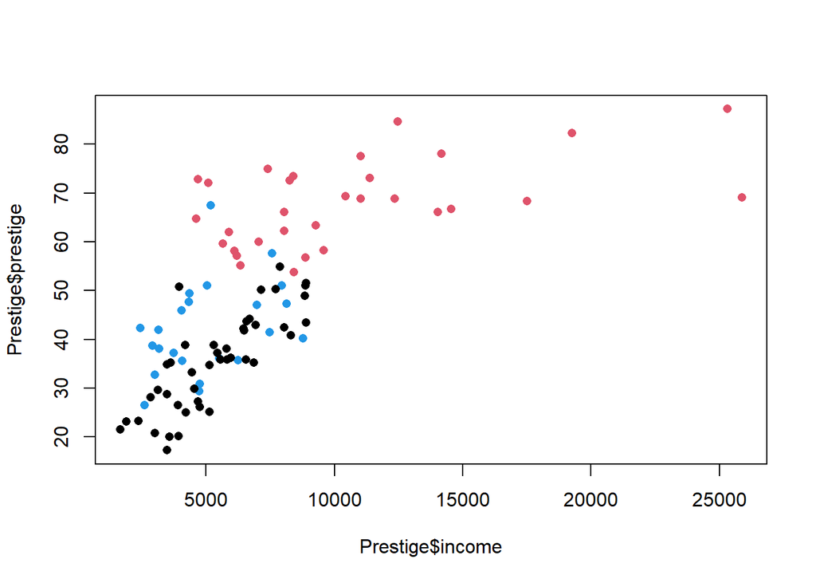

```r
col_type <- rep(1, length(Prestige$type))
col_type[Prestige$type == "wc"] <- 4
col_type[Prestige$type == "prof"] <- 2
plot(Prestige$income, Prestige$prestige, pch = 16, col = col_type)

# education = 10
# NOT WORKING
abline(a = coef(fit_intrinc)[1]+coef(fit_intrinc)[4]+coef(fit_intrinc)[5]*10,
       b = coef(fit_intrinc)[2]+coef(fit_intrinc)[7], col = 4)

abline(a = coef(fit_intrinc)[1]+coef(fit_intrinc)[3]+coef(fit_intrinc)[5]*10,
       b = coef(fit_intrinc)[2]+coef(fit_intrinc)[6], col = 2)

abline(a = coef(fit_intrinc)[1]+coef(fit_intrinc)[5]*10,
       b = coef(fit_intrinc)[2], col = 1)
```